# Eberle_Covid19Final

Ben Eberle

2024-08-16

Data Overview and Exploration

Before diving into the analysis, it’s important to understand the structure and contents of the dataset. This section will provide a summary and some basic exploratory analysis to help you get familiar with the data.

```r
# Import the data
confirmed <- read_csv("time_series_covid19_confirmed_global.csv")

# Overview of the data structure
glimpse(confirmed)
```

```
## Rows: 289
## Columns: 1,147
## $ State      <chr> NA, NA, NA, NA, NA, NA, NA, NA, NA, "Australian Capital Ter…
## $ Country    <chr> "Afghanistan", "Albania", "Algeria", "Andorra", "Angola", "…
## $ Lat        <dbl> 33.93911, 41.15330, 28.03390, 42.50630, -11.20270, -71.9499…
## $ Long       <dbl> 67.709953, 20.168300, 1.659600, 1.521800, 17.873900, 23.347…
## $ `1/22/20`  <dbl> 0, 0, 0, 0, 0, 0, 0, 0, 0, 0, 0, 0, 0, 0, 0, 0, 0, 0, 0, 0,…
## $ `1/23/20`  <dbl> 0, 0, 0, 0, 0, 0, 0, 0, 0, 0, 0, 0, 0, 0, 0, 0, 0, 0, 0, 0,…
## $ `1/24/20`  <dbl> 0, 0, 0, 0, 0, 0, 0, 0, 0, 0, 0, 0, 0, 0, 0, 0, 0, 0, 0, 0,…
## $ `1/25/20`  <dbl> 0, 0, 0, 0, 0, 0, 0, 0, 0, 0, 0, 0, 0, 0, 0, 0, 0, 0, 0, 0,…
## $ `1/26/20`  <dbl> 0, 0, 0, 0, 0, 0, 0, 0, 0, 0, 3, 0, 0, 0, 0, 1, 0, 0, 0, 0,…
## $ `1/27/20`  <dbl> 0, 0, 0, 0, 0, 0, 0, 0, 0, 0, 4, 0, 0, 0, 0, 1, 0, 0, 0, 0,…
## $ `1/28/20`  <dbl> 0, 0, 0, 0, 0, 0, 0, 0, 0, 0, 4, 0, 0, 0, 0, 1, 0, 0, 0, 0,…
## $ `1/29/20`  <dbl> 0, 0, 0, 0, 0, 0, 0, 0, 0, 0, 4, 0, 1, 0, 0, 1, 0, 0, 0, 0,…
## $ `1/30/20`  <dbl> 0, 0, 0, 0, 0, 0, 0, 0, 0, 0, 4, 0, 3, 0, 0, 2, 0, 0, 0, 0,…
```

[output cut: 1134 more lines]

```r
# Summary of key columns
#summary(confirmed)

# Check for missing values
missing_values <- confirmed %>%
  summarize_all(~ sum(is.na(.)))

# Print missing values summary
print(missing_values)
```

```
## # A tibble: 1 × 1,147
##   State Country   Lat  Long `1/22/20` `1/23/20` `1/24/20` `1/25/20` `1/26/20`
##   <int>   <int> <int> <int>     <int>     <int>     <int>     <int>     <int>
## 1   198       0     2     2         0         0         0         0         0
## # ℹ 1,138 more variables: `1/27/20` <int>, `1/28/20` <int>, `1/29/20` <int>,
## #   `1/30/20` <int>, `1/31/20` <int>, `2/1/20` <int>, `2/2/20` <int>,
## #   `2/3/20` <int>, `2/4/20` <int>, `2/5/20` <int>, `2/6/20` <int>,
## #   `2/7/20` <int>, `2/8/20` <int>, `2/9/20` <int>, `2/10/20` <int>,
## #   `2/11/20` <int>, `2/12/20` <int>, `2/13/20` <int>, `2/14/20` <int>,
## #   `2/15/20` <int>, `2/16/20` <int>, `2/17/20` <int>, `2/18/20` <int>,
## #   `2/19/20` <int>, `2/20/20` <int>, `2/21/20` <int>, `2/22/20` <int>, …
```

```r
# Exploratory Data Analysis (EDA)
# Calculate total cases per country
country_summary <- confirmed %>%
  pivot_longer(cols = starts_with("1/"),
               names_to = "date",
               values_to = "confirmed_cases") %>%
  mutate(date = mdy(date)) %>%
  group_by(Country) %>%
  summarize(total_cases = sum(confirmed_cases, na.rm = TRUE),
            max_daily_cases = max(confirmed_cases, na.rm = TRUE),
            first_case_date = min(date[confirmed_cases > 0])) %>%
  arrange(desc(total_cases))

# Display the top 10 countries by total cases
head(country_summary, 10)
```

```
## # A tibble: 10 × 4
##    Country        total_cases max_daily_cases first_case_date
##    <chr>                <dbl>           <dbl> <date>
##  1 US              5934153125       102362870 2020-01-22
##  2 India           2880600654        44684120 2020-01-30
##  3 Brazil          2121859121        36824580 2021-01-01
##  4 France          1769951707        38482878 2020-01-24
##  5 Germany         1479259564        37779833 2020-01-27
##  6 United Kingdom  1332560140        24274357 2020-01-31
##  7 Italy           1126784646        25453789 2020-01-31
##  8 Russia          1109957584        21640952 2020-01-31
##  9 Japan           1042055305        32555047 2020-01-22
## 10 Korea, South     948116473        30197066 2020-01-22
```

[figure not shown]

```r
# Visualization: Total Cases by Country
ggplot(country_summary, aes(x = reorder(Country, -total_cases), y = total_cases)) +
  geom_bar(stat = "identity", fill = "steelblue") +
  coord_flip() +
  theme_minimal() +
  labs(title = "Total Confirmed COVID-19 Cases by Country",
       x = "Country",
       y = "Total Confirmed Cases")
```

```r
# View the structure of the data
#str(confirmed)

# Tidy the data
confirmed_long <- confirmed %>%
  pivot_longer(cols = starts_with("1/"),
               names_to = "date",
               values_to = "confirmed_cases") %>%
  mutate(date = mdy(date)) %>%
  group_by(Country, date) %>%
  summarize(confirmed_cases = sum(confirmed_cases, na.rm = TRUE)) %>%
  ungroup()

# Check the first few rows of the tidy data
head(confirmed_long)
```

```
## # A tibble: 6 × 3
##   Country     date       confirmed_cases
##   <chr>       <date>               <dbl>
## 1 Afghanistan 2020-01-22               0
## 2 Afghanistan 2020-01-23               0
## 3 Afghanistan 2020-01-24               0
## 4 Afghanistan 2020-01-25               0
## 5 Afghanistan 2020-01-26               0
## 6 Afghanistan 2020-01-27               0
```

Exploratory Data Analysis (EDA)

Next, we perform some exploratory data analysis to calculate total cases per country and identify which countries were most affected.

```r
# Calculate total cases per country
country_summary <- confirmed %>%
  pivot_longer(cols = starts_with("1/"),
               names_to = "date",
               values_to = "confirmed_cases") %>%
  mutate(date = mdy(date)) %>%
  group_by(Country) %>%
  summarize(total_cases = sum(confirmed_cases, na.rm = TRUE),
            max_daily_cases = max(confirmed_cases, na.rm = TRUE),
            first_case_date = min(date[confirmed_cases > 0])) %>%
  arrange(desc(total_cases))

# Display the top 10 countries by total cases
head(country_summary, 10)
```

```
## # A tibble: 10 × 4
##    Country        total_cases max_daily_cases first_case_date
##    <chr>                <dbl>           <dbl> <date>
##  1 US              5934153125       102362870 2020-01-22
##  2 India           2880600654        44684120 2020-01-30
##  3 Brazil          2121859121        36824580 2021-01-01
##  4 France          1769951707        38482878 2020-01-24
##  5 Germany         1479259564        37779833 2020-01-27
##  6 United Kingdom  1332560140        24274357 2020-01-31
##  7 Italy           1126784646        25453789 2020-01-31
##  8 Russia          1109957584        21640952 2020-01-31
##  9 Japan           1042055305        32555047 2020-01-22
## 10 Korea, South     948116473        30197066 2020-01-22
```

Global and Country-Specific Trends

Global Trends of Confirmed COVID-19 Cases

We aggregate the data to observe the global trends in confirmed COVID-19 cases over time.

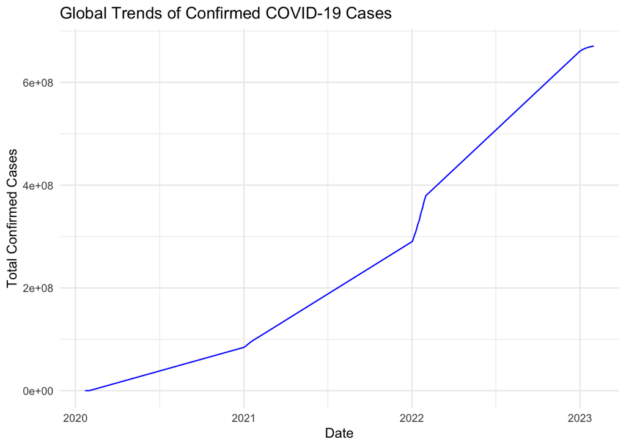

```r
# Aggregate data to see global trends
global_trend <- confirmed_long %>%
  group_by(date) %>%
  summarize(global_confirmed_cases = sum(confirmed_cases))

# Plot global trend over time
ggplot(global_trend, aes(x = date, y = global_confirmed_cases)) +
  geom_line(color = "blue") +
  theme_minimal() +
  labs(title = "Global Trends of Confirmed COVID-19 Cases",
       x = "Date",
       y = "Total Confirmed Cases")
```

Country-Specific Case Counts

We further analyze the trends for selected countries to compare their experiences during the pandemic.

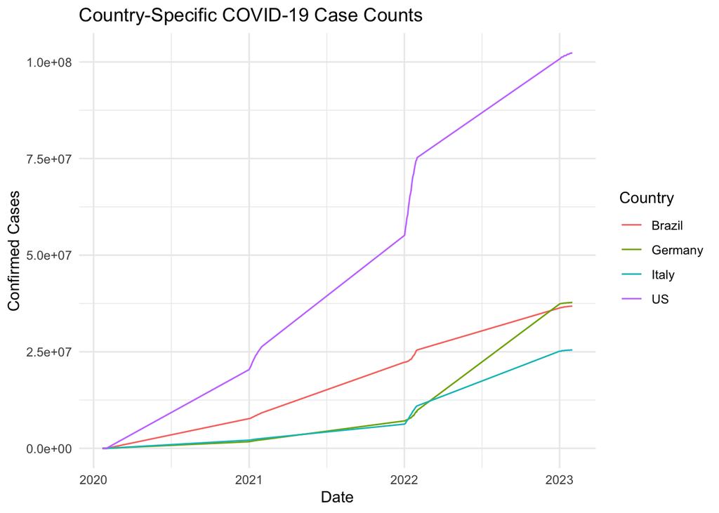

```r
# Select a few key countries for comparison
selected_countries <- c("US", "Italy", "South Korea", "Germany", "Brazil")

country_trend <- confirmed_long %>%
  filter(Country %in% selected_countries)

# Plot country-specific trends
ggplot(country_trend, aes(x = date, y = confirmed_cases, color = Country)) +
  geom_line() +
  theme_minimal() +
  labs(title = "Country-Specific COVID-19 Case Counts",
       x = "Date",
       y = "Confirmed Cases",
       color = "Country")
```

Modeling: Impact of Lockdowns on Growth Rate of Cases

Calculating Daily Growth Rate

To understand the impact of lockdowns, we calculate the daily growth rate of confirmed cases for each country.

```r
# Calculate daily growth rate
confirmed_long <- confirmed %>%
  pivot_longer(cols = starts_with("1/"),
               names_to = "date",
               values_to = "confirmed_cases") %>%
  mutate(date = mdy(date)) %>%
  group_by(Country) %>%
  arrange(date) %>%
  mutate(daily_growth_rate = (confirmed_cases - lag(confirmed_cases)) / lag(confirmed_cases) * 100) %>%
  ungroup()

# Remove rows with NA, NaN, or Inf in daily_growth_rate
confirmed_long <- confirmed_long %>%
  filter(is.finite(daily_growth_rate))
```

We model the impact of lockdowns on the daily growth rate using a linear model, focusing on a selected group of countries.

```r
# Calculate daily growth rate
confirmed_long <- confirmed_long %>%
  group_by(Country) %>%
  arrange(date) %>%
  mutate(daily_growth_rate = (confirmed_cases - lag(confirmed_cases)) / lag(confirmed_cases) * 100) %>%
  ungroup()

# Remove rows with NA, NaN, or Inf in daily_growth_rate
confirmed_long <- confirmed_long %>%
  filter(is.finite(daily_growth_rate))

# Check for any remaining problematic values
sum(is.na(confirmed_long$daily_growth_rate)) # should be 0
```

```
## [1] 0
```

```r
# Example lockdown dates for these countries
lockdown_dates <- tibble(
  Country = c("US", "Italy", "South Korea", "Germany", "Brazil"),
  lockdown_date = as.Date(c("2020-03-19", "2020-03-09", "2020-02-23", "2020-03-22", "2020-03-24"))
)

# Select the countries that were included in the model training
selected_countries <- c("US", "Italy", "South Korea", "Germany", "Brazil")

# Filter the dataset to only include these countries
model_data <- confirmed_long %>%
  filter(Country %in% selected_countries)

# Merge with lockdown dates
model_data <- model_data %>%
  left_join(lockdown_dates, by = "Country") %>%
  mutate(post_lockdown = ifelse(date >= lockdown_date, 1, 0))

# Fit the model again with the filtered data
model <- lm(daily_growth_rate ~ post_lockdown + Country, data = model_data)
summary(model)
```

```
##
## Call:
## lm(formula = daily_growth_rate ~ post_lockdown + Country, data = model_data)
##
## Residuals:
##       Min        1Q    Median        3Q       Max
##  -2688439   -617880   -422876        -2 252278936
##
## Coefficients:
##                  Estimate Std. Error t value Pr(>|t|)
## (Intercept)    -2.071e+06  4.350e+06  -0.476    0.634
## post_lockdown   2.071e+06  4.123e+06   0.502    0.616
## CountryGermany  4.230e+05  1.938e+06   0.218    0.827
## CountryItaly    1.424e+00  1.954e+06   0.000    1.000
## CountryUS       2.688e+06  1.938e+06   1.387    0.166
##
## Residual standard error: 13220000 on 375 degrees of freedom
## Multiple R-squared:  0.007271,   Adjusted R-squared:  -0.003318
## F-statistic: 0.6866 on 4 and 375 DF,  p-value: 0.6016
```

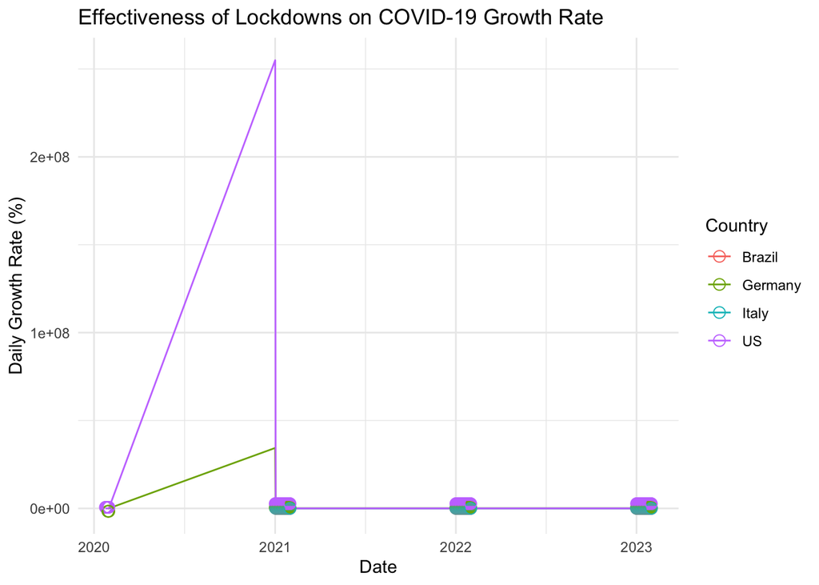

```r
# Predicting with the same countries
model_data <- model_data %>%
  mutate(predicted_growth_rate = predict(model, model_data))

# Visualization
ggplot(model_data, aes(x = date, y = daily_growth_rate, color = Country)) +
  geom_line() +
  geom_point(aes(y = predicted_growth_rate), shape = 1, size = 3) +
  theme_minimal() +
  labs(title = "Effectiveness of Lockdowns on COVID-19 Growth Rate",
       x = "Date",
       y = "Daily Growth Rate (%)",
       color = "Country")
```

Bias Analysis

4.1 Data Coverage and Selection Bias

Geographical Bias:

[output not shown]

Temporal Bias:

[output not shown]

Selection of Variables:

[output not shown]

4.2 Modeling Bias

Linear Assumptions:

[output not shown]

Lockdown Effectiveness:

[output not shown]

4.3 Data Quality and Reporting Bias

Reporting Bias:

[output not shown]

Data Completeness:

```
•   Description: Missing or incomplete data, especially in the early days of the pandemic, could lead to inaccurate growth rate calculations. For example, if case counts are not reported on certain days, this could artificially inflate or deflate the calculated growth rates.
•   Implications: Incomplete data can introduce significant errors into the model, especially if these gaps occur during critical periods (e.g., just before or after a lockdown). This could lead to incorrect inferences about the timing and effectiveness of interventions.
```

4.4 Analytical Bias

Simplification of Complex Relationships:

[output not shown]